# Week4_Assignment

KS

5/12/2021

# Introduction

This data set contains statistics, in arrests per 100,000 residents for assault, murder, and rape in each of the 50 US states in 1973. Also given is the percent of the population living in urban areas. A data frame with 50 observations on 4 variables.

[,1] Murder numeric Murder arrests (per 100,000) [,2] Assault numeric Assault arrests (per 100,000) [,3] UrbanPop numeric Percent urban population [,4] Rape numeric Rape arrests (per 100,000)

# Shiny Web Application

- The Shiny Web Application developed by using USArrests Dataset from inbuilt R package.
- The developed shiny App has 2 parts, a drop down box on left panel and main panel is on the right
- The Crime drop down box facilitates the user to choose 3 different crime rates in USA 1973
- Based on the selection in the drop down menu, it is possible to see the associated data,map,regression diagnostics on the tabs in the main panel.

Screenshots of the Server.R file

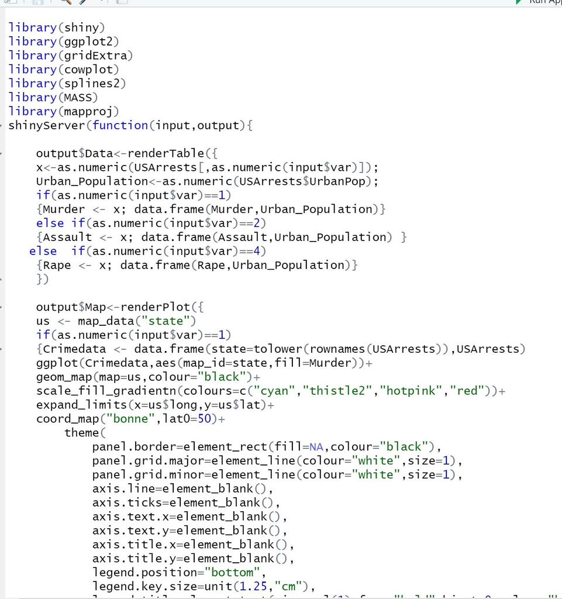

# Slide with R Output

```r
summary(USArrests)
```

```
##      Murder          Assault         UrbanPop          Rape
##  Min.   : 0.800   Min.   : 45.0   Min.   :32.00   Min.   : 7.30
##  1st Qu.: 4.075   1st Qu.:109.0   1st Qu.:54.50   1st Qu.:15.07
##  Median : 7.250   Median :159.0   Median :66.00   Median :20.10
##  Mean   : 7.788   Mean   :170.8   Mean   :65.54   Mean   :21.23
##  3rd Qu.:11.250   3rd Qu.:249.0   3rd Qu.:77.75   3rd Qu.:26.18
##  Max.   :17.400   Max.   :337.0   Max.   :91.00   Max.   :46.00
```

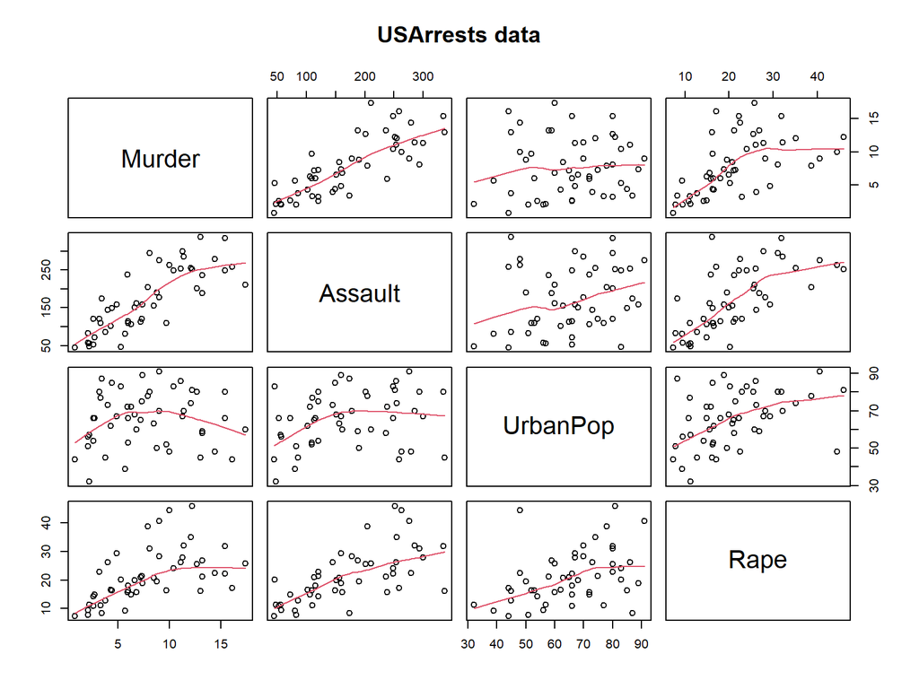

```r
require(graphics)
pairs(USArrests, panel = panel.smooth, main = "USArrests data")
```

```r
## Difference between 'USArrests' and its correction
USArrests["Maryland", "UrbanPop"] # 67 -- the transcription error
```

```
## [1] 67
```

```r
UA.C <- USArrests
UA.C["Maryland", "UrbanPop"] <- 76.6

## also +/- 0.5 to restore the original  <n>.5  percentages
s5u <- c("Colorado", "Florida", "Mississippi", "Wyoming")
s5d <- c("Nebraska", "Pennsylvania")
UA.C[s5u, "UrbanPop"] <- UA.C[s5u, "UrbanPop"] + 0.5
UA.C[s5d, "UrbanPop"] <- UA.C[s5d, "UrbanPop"] - 0.5
```

# Links

Follow the links for

- Shiny app viewer in ShinyIO. https://ks21.shinyapps.io/myApp/
- The code can be found at https://github.com/kavishant87/DevelopingDP_Week4Assn
- The Presentation can be found at https://rpubs.com/KaviS/DevelopingDP4